# Two-Way Basic Factorial Design

Prof Randi Garcia  
February 27, 2019

### Reading Free-Write (5 minutes)

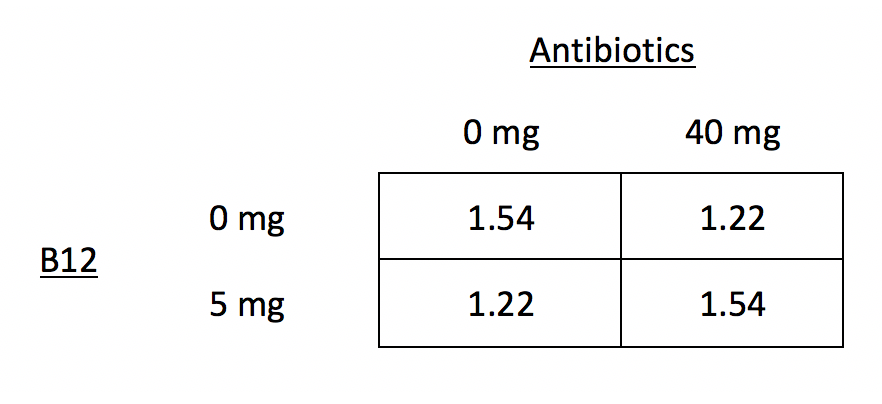

1. Sketch an interaction graph based on the set means (average daily weight gain) shown above. These factors are from the piglets example from your reading.
2. Give an interpretation for this interaction.

### Announcements

- HW5: Using software; Due 2/28 at 5p
  - Submit HTML file on Moodle
- Exam 1 passed out on Monday
- Dr. Emma Benn talk on Tuesday, Mar 5, at 5:00p in Seelye 106
  - Post comment on Slack channel #emmabenn
- Project next steps
  - Full class work time on Wed Mar 6
  - Updated project proposal due Friday Mar 8

### Agenda

- ANOVA table for the BF[1] Design
- The BF[2] design
- 10 min Group work time
  - Next steps?

### Parks and Recreation

Deputy director of the Pawnee Parks and Rec department, Leslie Knope, needs to know how resistant different vegetative types are to trampling so that the number of visitors can be controlled in sensitive areas. Twenty lanes of a park are established, each .5 m wide and 1.5 m long. These twenty lanes are randomly assigned to five treatments: 0, 25, 75, 200, or 500 walking passes. Each pass consists of a 70-kg individual wearing boots, walking in a natural gait. One year after trampling, the average height of the vegetation along the lanes are measured.

### ANOVA Source Table for BF[1]

- Using algebraic Notation

\[ {y}_{ij}=\mu+{\alpha}_{i}+{e}_{ij} \]

\[ {H}_{0}:{\alpha}_{1}={\alpha}_{2}=...={\alpha}_{a} \]

| Source | SS | df | MS | F |
| --- | --- | --- | --- | --- |
| Treatment | \( n\sum_{i=1}^{a}(\bar{y}_{i.}-\bar{y}_{..})^{2} \) | \( a-1 \) | \( \frac{{SS}_{Treatments}}{{df}_{Treatments}} \) | \( \frac{{MS}_{Treatments}}{{MS}_{E}} \) |
| Error | \( \sum_{i=1}^{a}\sum_{j=1}^{n}({y}_{ij}-\bar{y}_{i.})^{2} \) | \( N-a \) | \( \frac{{SS}_{E}}{{df}_{E}} \) |  |

### F-ratios and the F-distribution

Our test statistics in ANOVA is called the F ratio. It's our evidence again the null hypothesis that there are no treatment effects.

\[ F = \frac{{MS}_{Treatments}}{{MS}_{E}} \]

If the null hypothesis is true, then F is a random variable \( \sim F({df}_{Treatments}, {df}_{E}) \). The F-distribution.

### F-ratios and the F-distribution

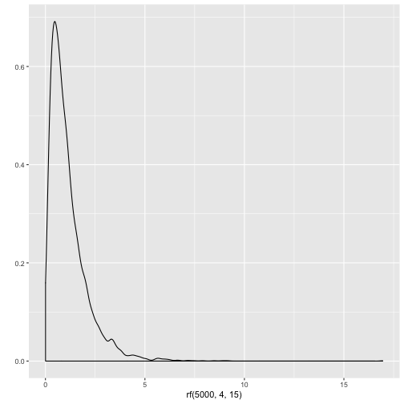

```r
library(ggplot2)
qplot(x = rf(5000, 4, 15), geom = "density")
```

### F-Test and the null hypothesis

\[ {H}_{0}:{\alpha}_{1}={\alpha}_{2}={\alpha}_{3}={\alpha}_{4}={\alpha}_{5} \]

where \( {\alpha}_{i} \) is the treatment effect for the \( i \)-th condition.

We can find the p-value for our F calculation (test statistic) with the following code

```r
pf(29.484, 4, 15, lower.tail = FALSE)
```

## Basic Factorial Two-Way BF[2]

### Piglets

It seems natural to think that adding the right vitamins to a pig's diet might produce fatter pigs faster. You've decided to study the effects of B12 in two doses (0mg and 5mg). But pigs have bacteria living in their intestines that might prevent the uptake of vitamins, so you decided to give antibiotics to the pigs in one of two doses (0mg or 40 mg). You design your experiment in such a way that 3 piglets are randomly assigned to each of the 4 treatment conditions. You measure their weight every day, and take each pig's average daily weight gain as your final number recorded.

### Principal of Factorial Crossing

Two sets of treatments are **crossed** if all possble combinations of treatments occur in the design. The design in called a **two-way factorial** if there are two factors that are crossed, and it is then said to have a **factorial treatment structure**.

### Research Questions in a BF[2] Design

1. Does treatment A have an effect on the response variable?
   - Is there a main effect of factor 1?
2. Does treatment A have an effect on the response variable?
   - Is there a main effect of factor 2?
3. Does being in a specific combination of treatments have an effect over and above the additive effects of treatment A and B alone?
   - Is there an interaction between factor 1 and factor two?

### Interaction Mantra

An interaction is present if the effect of one factor is different across levels of the other factor.

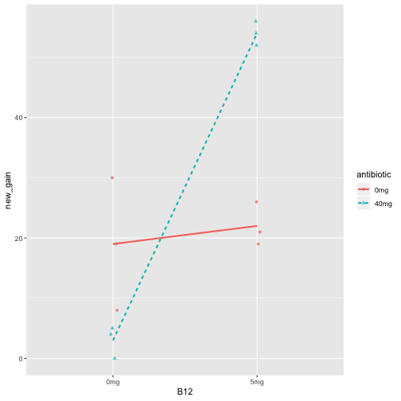

### Interaction Graphs

For each of the following interaction graphs, answer the following questions with **YES** or **NO**.

1. Is there a main effect of B12?
2. Is there a main effect of antibiotics?
3. Is there an interaction between B12 and antibiotics?

### Practice 1

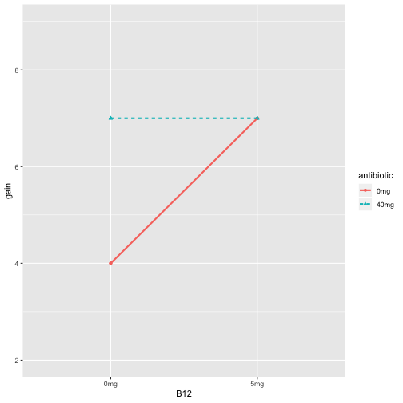

### Practice 1

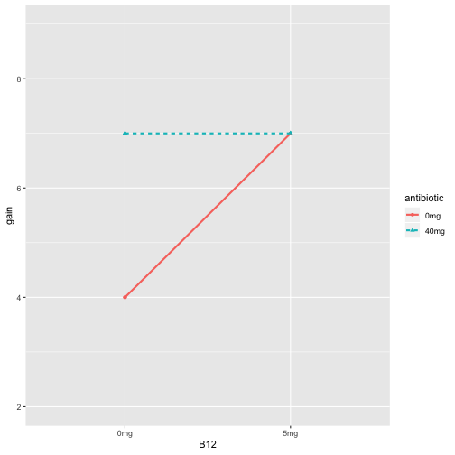

1. YES
2. YES
3. YES

### Practice 2

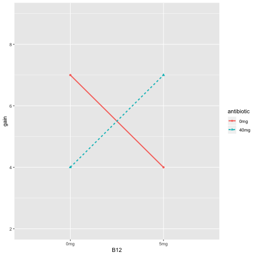

### Practice 2

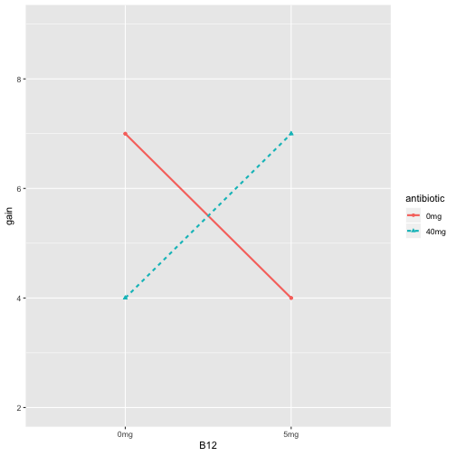

1. NO
2. NO
3. YES

### Practice 3

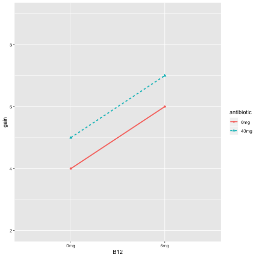

### Practice 3

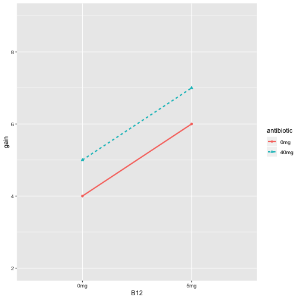

1. YES
2. YES
3. NO

### Practice 4

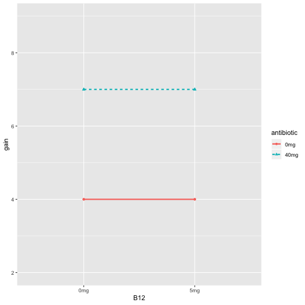

### Practice 4

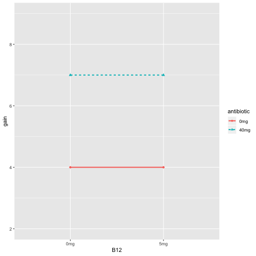

1. NO
2. YES
3. NO

### Inside-outside Factors

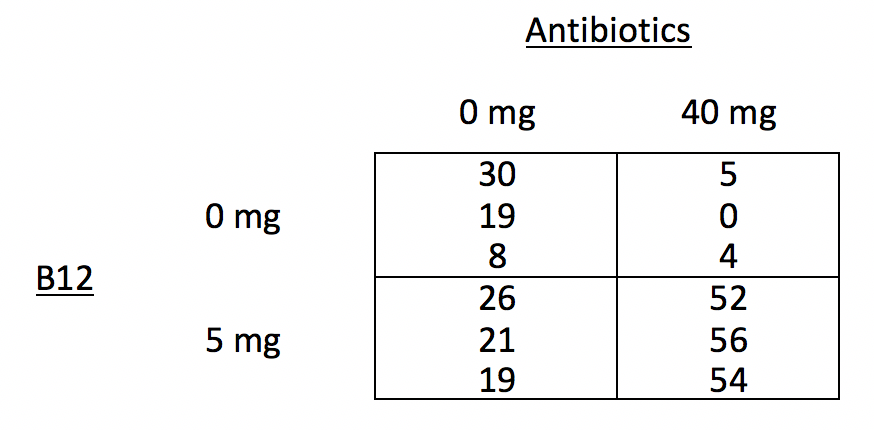

- Draw the factor diagram vertically and label all inside and outside factors with arrows. Include the universal factors (benchmark and residuals).

### Mathematical notation

\[ {y}_{ijk}={\mu}+{\alpha}_{i}+{\beta}_{j}+{\alpha\beta}_{ij}+{e}_{ijk} \]

- Where \( i \), from 1 to \( a \), is the level of the first factor,
- \( j \), from 1 to \( b \), is the level of the second factor,
- and \( k \), from 1 to \( n \), is the observation in each cell.

### Sum of Squares (SS)

\[ {SS}_{A} = \sum_{i=1}^{a}bn(\bar{y}_{i..}-\bar{y}_{…})^{2} \]

\[ {SS}_{B} = \sum_{j=1}^{b}an(\bar{y}_{.j.}-\bar{y}_{…})^{2} \]

\[ {SS}_{AB} = n\sum_{i=1}^{a}\sum_{j=1}^{b}(\bar{y}_{ij.}-\bar{y}_{i..}-\bar{y}_{.j.}+\bar{y}_{…})^{2} \]

\[ {SS}_{E} = \sum_{i=1}^{a}\sum_{j=1}^{b}\sum_{k=1}^{n}({y}_{ijk}-\bar{y}_{ij.})^{2} \]

### Degrees of Freedom (df)

\[ {df}_{A}=a-1 \]

\[ {df}_{B}=b-1 \]

\[ {df}_{AB}=(a-1)(b-1) \]

\[ {df}_{E}=ab(n-1) \]

### Mean Squares (MS)

\[ {MS}_{A}=\frac{{SS}_{A}}{{df}_{A}} \]

\[ {MS}_{B}=\frac{{SS}_{B}}{{df}_{B}} \]

\[ {MS}_{AB}=\frac{{SS}_{AB}}{{df}_{AB}} \]

\[ {MS}_{E}=\frac{{SS}_{E}}{{df}_{E}} \]

### F-ratios and the F-distribution

The ultimate statistics we want to calculate is Variability in treatment effects/Variability in residuals. The F-ratio.

\[ F = \frac{{MS}_{A}}{{MS}_{E}} \]

\[ F = \frac{{MS}_{B}}{{MS}_{E}} \]

\[ F = \frac{{MS}_{AB}}{{MS}_{E}} \]

### ANOVA Source Table for BF[2]

\[ {y}_{ijk}={\mu}+{\alpha}_{i}+{\beta}_{j}+{\alpha\beta}_{ij}+{e}_{ijk} \]

| Source | SS | df | MS | F |
| --- | --- | --- | --- | --- |
| Treatment A | \( \sum_{i=1}^{a}bn(\bar{y}_{i..}-\bar{y}_{…})^{2} \) | \( a-1 \) | \( \frac{{SS}_{A}}{{df}_{A}} \) | \( \frac{{MS}_{A}}{{MS}_{E}} \) |
| Treatment B | \( \sum_{j=1}^{b}an(\bar{y}_{.j.}-\bar{y}_{…})^{2} \) | \( b-1 \) | \( \frac{{SS}_{B}}{{df}_{B}} \) | \( \frac{{MS}_{B}}{{MS}_{E}} \) |
| Interaction AB | \( n\sum_{i=1}^{a}\sum_{j=1}^{b}(\bar{y}_{ij.}-\bar{y}_{i..}-\bar{y}_{.j.}+\bar{y}_{…})^{2} \) | \( (a-1)(b-1) \) | \( \frac{{SS}_{AB}}{{df}_{AB}} \) | \( \frac{{MS}_{AB}}{{MS}_{E}} \) |
| Error | \( \sum_{i=1}^{a}\sum_{j=1}^{b}\sum_{k=1}^{n}({y}_{ijk}-\bar{y}_{ij.})^{2} \) | \( ab(n-1) \) | \( \frac{{SS}_{E}}{{df}_{E}} \) |  |

### BF[2] in R

[See BF2 code](http://www.science.smith.edu/%7Ergarcia/sds290-S19/lectures/09_bf2_inR.Rmd)